# Launches

Pao

November 10, 2019

## Datos

```r
library(tidyverse)
agencias <- read_csv("https://raw.githubusercontent.com/rfordatascience/tidytuesday/master/data/2019/2019-01-15/agencies.csv")
lanzamientos <- read_csv("https://raw.githubusercontent.com/rfordatascience/tidytuesday/master/data/2019/2019-01-15/launches.csv")
```

Queremos ver como evolucionó el lanzamiento de cohetes a lo largo del tiempo.

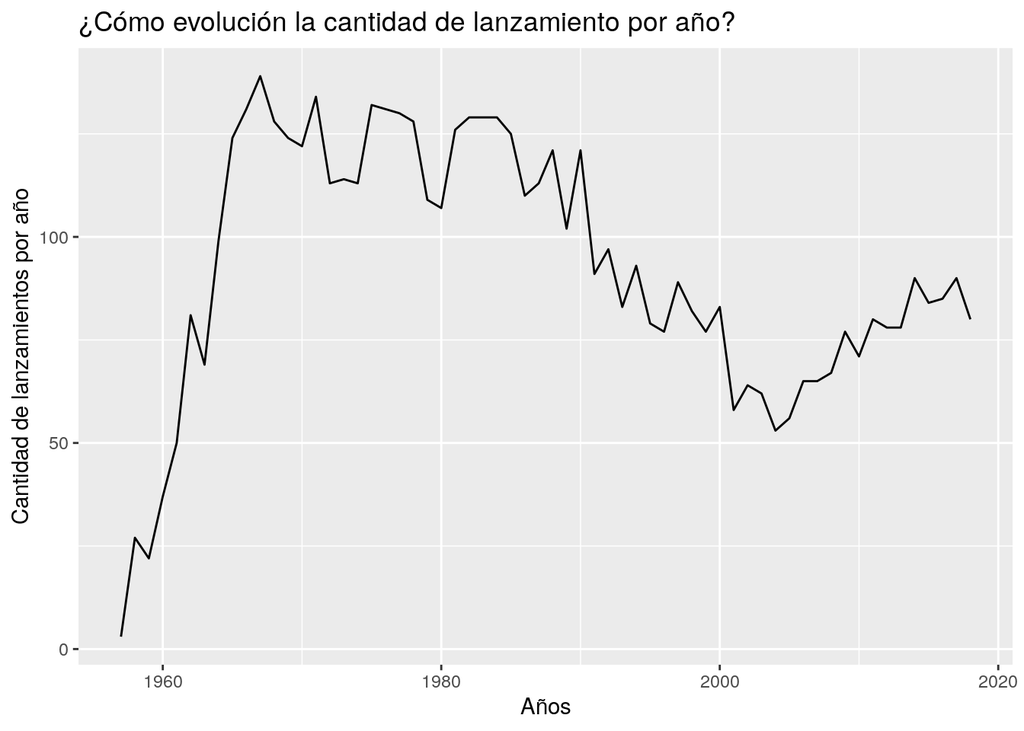

```r
lanzamientos %>%
  count(launch_year) %>%
  ggplot(aes(launch_year, n)) +
  geom_line() +
  labs(x = "Años",
       y = "Cantidad de lanzamientos por año",
       title = "¿Cómo evolución la cantidad de lanzamiento por año?")
```

Se ve el auge inicial justo antes de los 60, mucho ruido en el medio y luego de un mínimo post 2000 un nuevo crecimiento. ¿A que se deberá este nuevo crecimiento?

Hay agencias publicas, como la NASA, privadas y startups. No se cual será la diferencia entre las dos últimas. Pero imagino que al principio eran todas del gobierno y luego aparecieron las privadas. Será que el crecimiento de los últimos 20 años se debe a agencias como SpaceX?

```r
lanzamientos %>%
  count(agency_type, sort = TRUE)
```

```
## # A tibble: 3 x 2
##   agency_type     n
##   <chr>       <int>
## 1 state        4776
## 2 private       880
## 3 startup        70
```

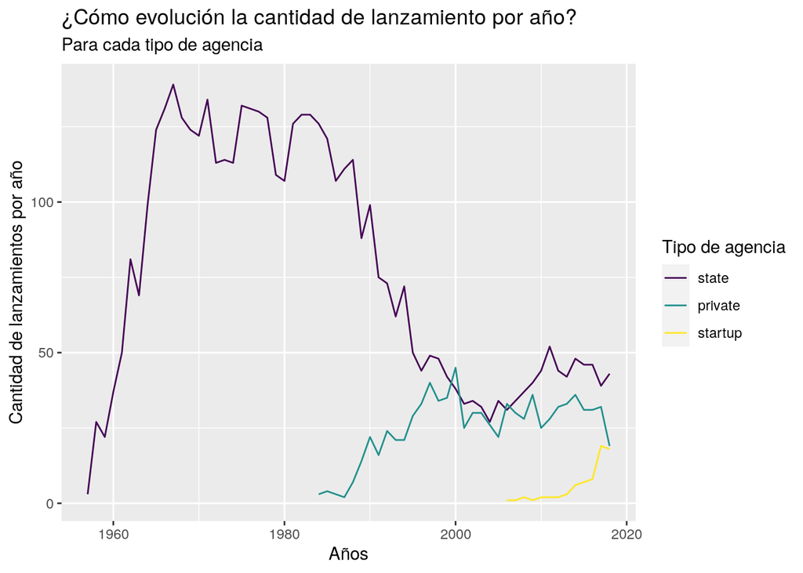

```r
lanzamientos %>%
  group_by(agency_type) %>%
  count(launch_year) %>%
  ungroup() %>%
  mutate(agency_type = fct_reorder(agency_type, -n, sum)) %>%
  ggplot(aes(launch_year, n)) +
  geom_line(aes(color = agency_type)) +
  scale_color_viridis_d(name = "Tipo de agencia") +
  labs(x = "Años",
       y = "Cantidad de lanzamientos por año",
       title = "¿Cómo evolución la cantidad de lanzamiento por año?",
       subtitle = "Para cada tipo de agencia")
```

Genial, me interesan las internas EE.UU. y Rusia. Veamos que pasa por paises.

```r
lanzamientos %>%
  count(state_code, sort = TRUE)
```

```
## # A tibble: 17 x 2
##    state_code     n
##    <chr>      <int>
##  1 SU          2444
##  2 US          1716
##  3 RU           734
##  4 CN           302
##  5 F            291
##  6 J            115
##  7 IN            65
##  8 I-ESA         13
##  9 IL            10
## 10 I              9
## 11 IR             8
## 12 KP             5
## 13 CYM            4
## 14 I-ELDO         3
## 15 KR             3
## 16 BR             2
## 17 UK             2
```

Oops! Acá hay que tener en cuenta que Russia y Unión sovietica son la “misma” cosa. Pero seguro que lanzaron más cosas que EE.UU.

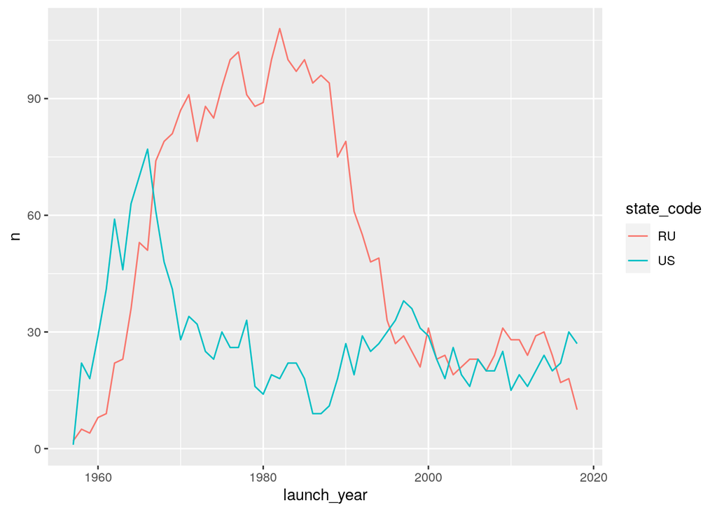

```r
lanzamientos %>%
  mutate(state_code = if_else(state_code == "SU", "RU", state_code)) %>%
  filter(state_code %in% c("RU", "US")) %>%
  count(launch_year, state_code, sort = TRUE) %>%
  ggplot(aes(launch_year, n)) +
  geom_line(aes(color = state_code))
```

Bueno, parece que a EEUU se le acabó la nafta después de Mercury/Apollo. ¿Me pregunto que habrán lanzando todo ese tiempo? Satélites? Vuelvo a ver que pasa con las privadas/startups porque SpaceX está de moda.

```r
lanzamientos
```

```
## # A tibble: 5,726 x 11
##    tag       JD launch_date launch_year type  variant mission agency
##    <chr>  <dbl> <date>            <dbl> <chr> <chr>   <chr>   <chr>
##  1 1967… 2.44e6 1967-06-29         1967 Thor… <NA>    Secor … US
##  2 1967… 2.44e6 1967-08-23         1967 Thor… <NA>    DAPP 3… US
##  3 1967… 2.44e6 1967-10-11         1967 Thor… <NA>    DAPP 4… US
##  4 1968… 2.44e6 1968-05-23         1968 Thor… <NA>    DAPP 5… US
##  5 1968… 2.44e6 1968-10-23         1968 Thor… <NA>    DAPP 6… US
##  6 1969… 2.44e6 1969-07-23         1969 Thor… <NA>    DAPP 7… US
##  7 1970… 2.44e6 1970-02-11         1970 Thor… <NA>    DAPP B… US
##  8 1970… 2.44e6 1970-09-03         1970 Thor… <NA>    DAPP B… US
##  9 1971… 2.44e6 1971-02-17         1971 Thor… <NA>    DAPP B… US
## 10 1971… 2.44e6 1971-06-08         1971 Thor… <NA>    P70-1   US
## # … with 5,716 more rows, and 3 more variables: state_code <chr>,
## #   category <chr>, agency_type <chr>
```